# Practical Machine Learning Coursera-JHU

Pere Gadea

Sunday, January 25, 2015

### Introduction & Strategy

First, analyze the variables of the database in order to reduce their number by various techniques. Subsequently, we will analyze the data according to different models, and finally, select the best performing model and reach conclusions.

### Exploration

First, load the dataset

```r
data <- read.csv("pml-training.csv", header=T)
```

We take a look at the variables of the dataset, and determine if any changes are needed.

```r
str(data)
summary(data)
```

First, we analyze the existence of NA values, and if we find that for some variables there are plenty of NA values, discard the variable.

```r
na_validation = sapply(data, function(x) {sum(is.na(x))})
table(na_validation)
delete_NA = names(na_validation[na_validation==19216])
data = data[, !names(data) %in% delete_NA]
```

We removed 67 features.

It is also interesting to delete columns that do not provide information to the accuracy of the model, such as those relating to the identification of subjects, so, we must delete the first 7 variables.

```r
data <- data[-c(1:7)]
```

I decide to check whether the variability of other features is significant, and if not, remove the dataset variables.

```r
library(caret); suppressMessages(library(caret))
trainZero <- nearZeroVar(data)
data <- data[-trainZero]
```

33 variables are deleted.

### Model selection

We split the data into two subsets: a database for model (train) and one for validation (test).

```r
set.seed(0)
inTrain = createDataPartition(y=data$classe, p=0.7, list=FALSE)
train = data[inTrain,]
test = data[-inTrain,]
```

Considering the large number of variables, first check the linear discriminant analysis. We try find a linear combination of features which characterizes classes.

```r
library(MASS)
modLda <- train(classe ~ ., data=train, method="lda")
preLda <- predict(modLda, test)
modLda
```

```
## Linear Discriminant Analysis
##
## 13737 samples
##    52 predictor
##     5 classes: 'A', 'B', 'C', 'D', 'E'
##
## No pre-processing
## Resampling: Bootstrapped (25 reps)
##
## Summary of sample sizes: 13737, 13737, 13737, 13737, 13737, 13737, ...
##
## Resampling results
##
##   Accuracy   Kappa      Accuracy SD  Kappa SD
##   0.6992463  0.6193345  0.005882927  0.007291919
##
##
```

An 69% accuracy is achieved with this model. It is not an acceptable outcome.

Second, we try a random forest model, which usually performs a better fit.

```r
library(randomForest)
modForest <- randomForest(classe ~ ., data=train)
predForest <- predict(modForest, test)

confusionMatrix(predForest, test$classe)
```

```
## Confusion Matrix and Statistics
##
##           Reference
## Prediction    A    B    C    D    E
##          A 1672    4    0    0    0
##          B    1 1134    1    0    0
##          C    0    1 1024    8    1
##          D    0    0    1  956    2
##          E    1    0    0    0 1079
##
## Overall Statistics
##
##                Accuracy : 0.9966
##                  95% CI : (0.9948, 0.9979)
##     No Information Rate : 0.2845
##     P-Value [Acc > NIR] : < 2.2e-16
##
##                   Kappa : 0.9957
##  Mcnemar's Test P-Value : NA
##
## Statistics by Class:
##
##                      Class: A Class: B Class: C Class: D Class: E
## Sensitivity            0.9988   0.9956   0.9981   0.9917   0.9972
## Specificity            0.9991   0.9996   0.9979   0.9994   0.9998
## Pos Pred Value         0.9976   0.9982   0.9903   0.9969   0.9991
## Neg Pred Value         0.9995   0.9989   0.9996   0.9984   0.9994
## Prevalence             0.2845   0.1935   0.1743   0.1638   0.1839
## Detection Rate         0.2841   0.1927   0.1740   0.1624   0.1833
## Detection Prevalence   0.2848   0.1930   0.1757   0.1630   0.1835
## Balanced Accuracy      0.9989   0.9976   0.9980   0.9955   0.9985
```

We get teh features with more impact in the model, and plot some graphics.

```r
library(caret)
principals <- order(varImp(modForest), decreasing=T)
names(test[principals])[1:4]
```

```
## [1] "roll_belt"         "yaw_belt"          "magnet_dumbbell_z"
## [4] "pitch_forearm"
```

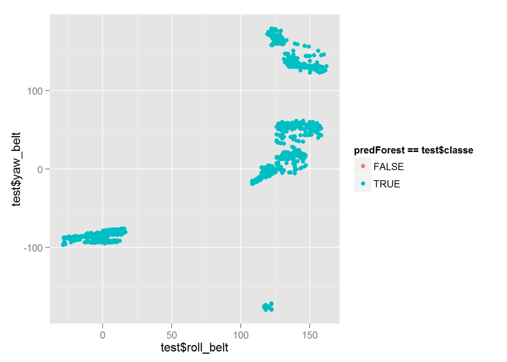

```r
qplot(test$roll_belt, test$yaw_belt, colour= predForest == test$classe, data=test)
```

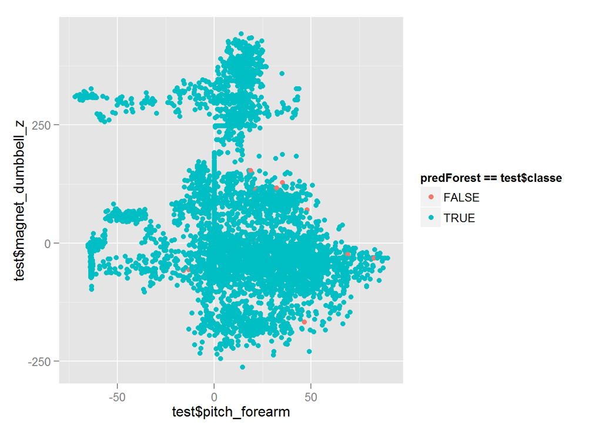

```r
qplot(test$pitch_forearm, test$magnet_dumbbell_z, colour= predForest == test$classe, data=test)
```

### Cite

Velloso, E.; Bulling, A.; Gellersen, H.; Ugulino, W.; Fuks, H. Qualitative Activity Recognition of Weight Lifting Exercises. Proceedings of 4th International Conference in Cooperation with SIGCHI (Augmented Human ’13). Stuttgart, Germany: ACM SIGCHI, 2013.

Read more: http://groupware.les.inf.puc-rio.br/har#ixzz3PrbGnPw5

### Annex

To validate the model with control data and refer to Coursera.

```r
submissionTesting <- read.csv("pml-testing.csv", header=T)

answers <- predict(modForest, submissionTesting)

pml_write_files = function(x){
      n = length(x)
      for(i in 1:n){
            filename = paste0("problem_id_",i,".txt")
            write.table(x[i],file=filename,quote=FALSE,row.names=FALSE,col.names=FALSE)
      }
}

pml_write_files(answers)
```